# More advanced plotting with ggplot2

Code and comments

Date: 2023-07-17

# Plotting with ggplot2

This document will demonstrate a few a little more advanced examples of plots drawn using ggplot2. These example include:

1. Conservation plot:
   - Annotating the plot with line segments.
   - Plotting sequence motifs from the matrix and visualizing them within the plot.
2. A composite plots that includes images:
   - Automatically plotting images.
   - Combining images with plots.

## Plotting TF motifs within the plot

This is the conservation plot example, where line-plot is annotated with coloured lines and motif logos to indicate the location of the TF binding motif. Each step will be executed and visualized.

### Input

In the beginning, we will need a few files and parameters. Conservation files for real and random observations as well as core and co-binder motif matrices that will be used to plot the motifs. Motif location is defined as a parameter here.

```r
## Conservation files:
cons_file        <- "conservation_plot/CTCF_conservation.tsv"
random_cons_file <- "conservation_plot/CTCF_conservation_random.tsv"

## Motifs:
cobinder_file <- "conservation_plot/cobinder_0.txt"
core_file     <- "conservation_plot/core_0.txt"

## Motif grammar:
location <- "left"
spacing  <- "13"
```

We read all input files:

```r
## Conservation files:
cons   <- data.table::fread(cons_file, header = FALSE)
random <- data.table::fread(random_cons_file, header = FALSE)

df   <- cbind(cons, random[,2])
colnames(df) <- c("dist", "Observed", "Random")

df <- df %>%
    dplyr::select(dist, Observed, Random) %>%
    gather(key = "Track", value = "value", -dist)

## Motif files:
cobinder_matrix <- data.table::fread(cobinder_file, header = FALSE)
core_matrix     <- data.table::fread(core_file, header = FALSE)
```

Below you can see how unprocessed conservation input table looks like. We take two of these tables and put them in a single dataframe that is used later in plotting.

| V1 | V2 |
| --- | --- |
| -50 | 0.0936913863428646 |
| -49 | 0.0909354454889672 |
| -48 | 0.0924131506724115 |
| -47 | 0.0926600061365714 |
| -46 | 0.0898711945423685 |
| -45 | 0.0882283134874004 |
| -44 | 0.088307860033947 |
| -43 | 0.0866163440396919 |
| -42 | 0.0869411115028072 |
| -41 | 0.089768175218697 |

[output cut: 90 more lines]

**Table 1. Conservation data**. Example table with real observations

Below is an example of the motif matrix format that is used in this plotting. It is later processed to fulfill `ggseqlogo` requirements.

| V1 | V2 | V3 | V4 |
| --- | --- | --- | --- |
| 0.732149 | 0.032847 | 0.127672 | 0.107333 |
| 0.043005 | 0.576965 | 0.352729 | 0.027301 |
| 0.154035 | 0.437185 | 0.076371 | 0.332409 |
| 0.834983 | 0.028972 | 0.087093 | 0.048952 |
| 0.011696 | 0.002182 | 0.982426 | 0.003696 |
| 0.419504 | 0.003289 | 0.571785 | 0.005421 |
| 0.039622 | 0.021761 | 0.524714 | 0.413903 |
| 0.020478 | 0.004265 | 0.966948 | 0.008309 |
| 0.037937 | 0.052247 | 0.825838 | 0.083978 |
| 0.128704 | 0.746734 | 0.02573 | 0.098831 |

**Table 2. Motif data**. Example of a core motif

### Plotting conservation data

We are now plotting the conservation tracks only without any annotations.

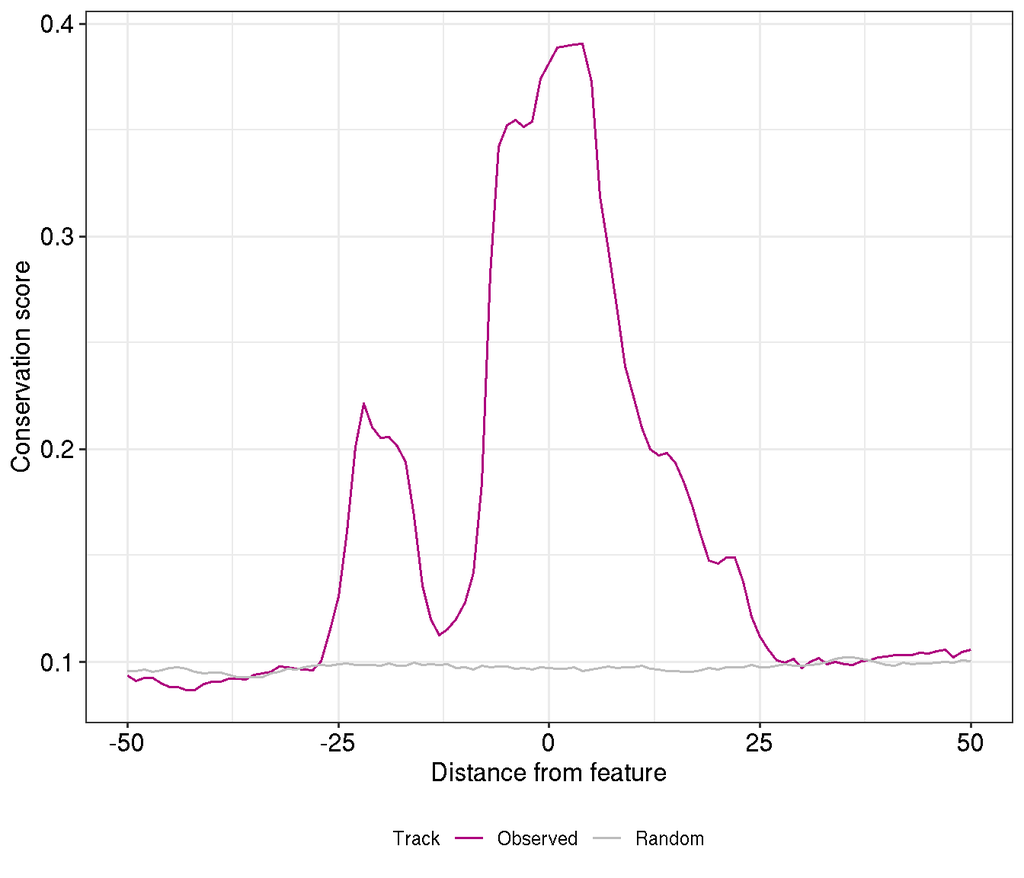

**Figure 1. Conservation plot**

```r
colors <- c("#ae017e", "#bdbdbd")

## Conservation base plot:
conservation_plot <- ggplot(
        df,
        aes(x = dist, y = value)) +
    geom_line(aes(color = Track)) +
    scale_color_manual(values = colors) +
    theme_bw() +
    xlab("Distance from feature") +
    ylab("Conservation score") +
    theme(legend.position = "bottom") +
    theme(
        plot.title = element_text(size = 14),
        axis.title = element_text(size = 16, colour = "black"),
        axis.text = element_text(size = 14, colour = "black")
    )

conservation_plot
```

### Annotating the plot

We need to define the locations of our annotations and motif plots. We define them using parameters for core and cobinder.

```r
cobinder_size <- nrow(cobinder_matrix)
core_size     <- nrow(core_matrix)

window_size   <- nrow(random)

core_end   <- (core_size / 2)
core_start <- ((-1 * core_size) / 2)

if (location == "left") {
    spacing       <- (-1 * as.numeric(spacing))
    cobinder_size <- (-1 * cobinder_size)
}

cobinder_end   <- core_start + spacing
cobinder_start <- cobinder_end + cobinder_size

core_segment     <- data.frame(
    x    = core_start,
    xend = core_end,
    y    = 0,
    yend = 0)
cobinder_segment <- data.frame(
    x    = cobinder_start,
    xend = cobinder_end,
    y    = 0,
    yend = 0)
```

We annotate motif locations with segments in different colours.

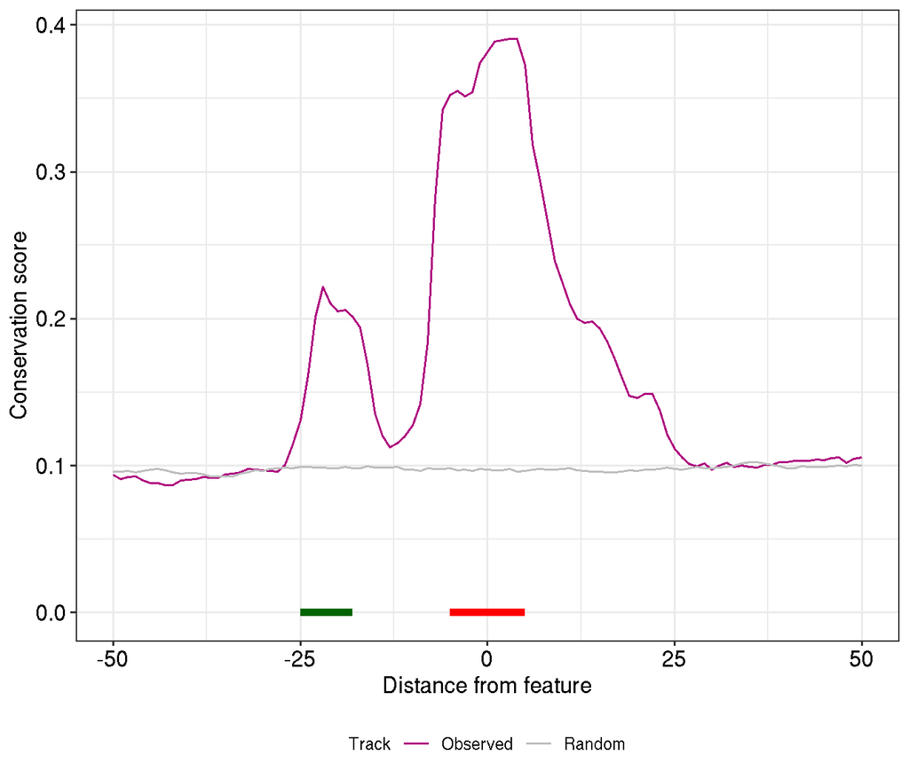

**Figure 2. Conservation plot with specified motif locations**

```r
conservation_plot <- conservation_plot +
    geom_segment(data = core_segment,
                aes(x = x, y = y, yend = yend, xend = xend),
                inherit.aes = FALSE,
                colour = "red", linewidth = 2,
                show.legend = NA) +
    geom_segment(data = cobinder_segment,
                aes(x = x, y = y, yend = yend, xend = xend),
                inherit.aes = FALSE,
                colour = "darkgreen", linewidth = 2)

conservation_plot
```

We will draw our motif logos from the matrices. We want these logos to be very minimalistic - without axis lines or text. These individual motif plots will be then used to insert on the conservation track plots.

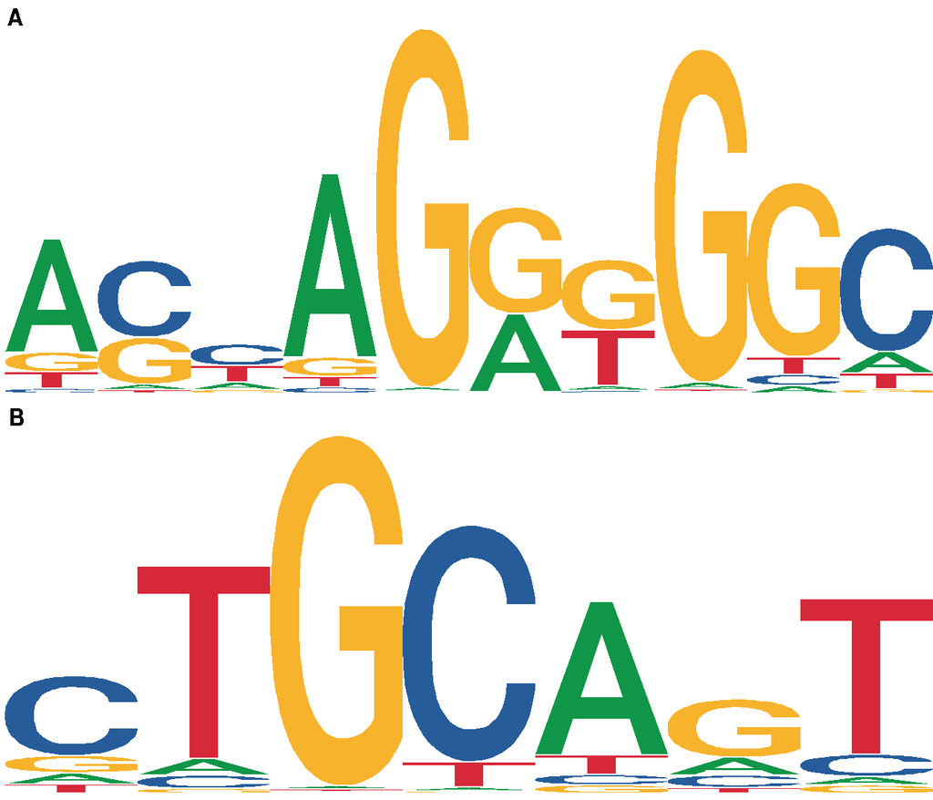

**Figure 3. Motif logos**. **A** - core, **B** - cobinder

```r
plot_motif <- function(motif_matrix) {
    motif_logo <- ggplot() +
        geom_logo(motif_matrix, method = 'bits', stack_width = 1) +
        theme_logo() +
        scale_x_continuous(expand = c(0, 0)) +
        scale_y_continuous(limits = c(0,2), expand = c(0, 0)) +
        theme(axis.text.x = element_blank(),
                axis.title.y = element_blank(),
                axis.text.y = element_blank(),
                panel.grid = element_blank(),
                axis.line=element_blank(),
                axis.text = element_blank(),
                axis.ticks=element_blank(),
                axis.title = element_blank(),
                panel.border=element_blank(),
                panel.spacing = unit(0, "cm"),
                panel.grid.major=element_blank(),
                panel.grid.minor=element_blank(),
                plot.margin = margin(0, 0, 0, 0, "cm"))
    return(motif_logo)
}
## Cobinder matrix:
colnames(cobinder_matrix) <- c("A", "C", "G", "T")
cobinder_matrix <- t(cobinder_matrix)
cobinder_logo   <- plot_motif(cobinder_matrix)
## Core matrix:
colnames(core_matrix) <- c("A", "C", "G", "T")
core_matrix <- t(core_matrix)
core_logo   <- plot_motif(core_matrix)
## Combining plot for display:
combined_plot <- cowplot::plot_grid(
    core_logo, cobinder_logo,
    labels = c("A", "B"),
    ncol = 1, nrow = 2)

combined_plot
```

To insert motifs onto the conservation plot, we will use a function that creates a layer with the motif that can be added with `+`. You can read more information about the `annotation_custom` function [here](https://ggplot2.tidyverse.org/reference/annotation_custom.html). Motif logo plots are inserted as [grobs](https://genviz.org/module-07-appendix/0007/01/01/advancedggplot2/#:~:text=First%20off%20a%20grob%20is,because%20ggplot2%20uses%20grid%20underneath.). `grob` is short for `grid graphical object` and is a set of instruction to create a graphical object. `ggplot2` uses grobs behind the scenes, so it is good to be aware of them.

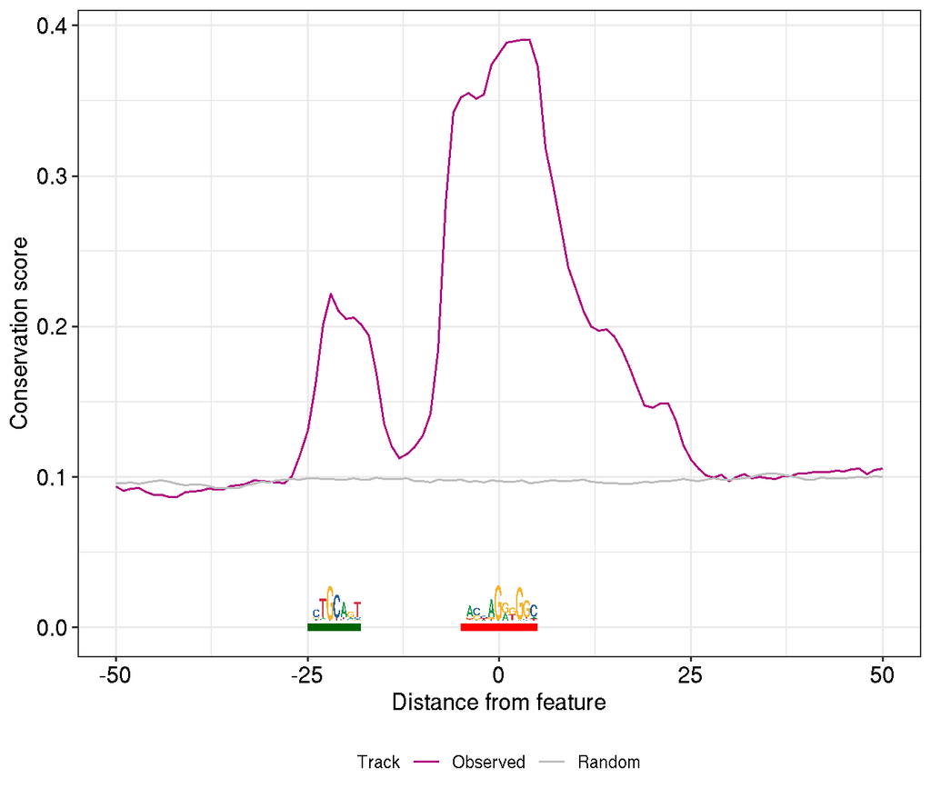

**Figure 4. Conservation plot with visualized motifs and their locations**

```r
## Adding motifs to the plot:
conservation_plot <- conservation_plot +
    annotation_custom(
        ggplotGrob(core_logo),
        xmin = core_segment$x,
        xmax = core_segment$xend,
        ymin = 0.0005,
        ymax = round(max(df$value)/12, 2)) +
    annotation_custom(
        ggplotGrob(cobinder_logo),
        xmin = cobinder_segment$x,
        xmax = cobinder_segment$xend,
        ymin = 0.0005,
        ymax = round(max(df$value)/12, 2))

conservation_plot
```

```r
## Expporting the plot:
ggsave(
    plot      = conservation_plot,
    filename  = file.path("conservation_plot_example_with_annotations.pdf"),
    width     = 7,
    height    = 6,
    limitsize = FALSE)
```

## Plotting PNG images in the plots

In the second example, we will see how one can plot images in `png` format onto the plot or make a composite plot to view the results in a convenient way.

### Input

As input we use pre-processed data frame with information on PPI matches and motif similarities between a motif of interest and libraries of known motifs and PPI data.

```r
ppi_table_path <- "ppi_plot/PPI_tab.tsv"

ppi_table <- data.table::fread(ppi_table_path, header = TRUE)
```

| cobinder_id | cobinder_name | cobinder_motif_id | log10_p_value | log10_E_value | log10_q_value | tf_pair | pair_label | combined_score | TOMTOMbyPPI | alignment_png |
| --- | --- | --- | --- | --- | --- | --- | --- | --- | --- | --- |
| cobinder_0 | POU5F1 | M09222_2.00 | 8.96527932072869 | 5.14507666635339 | 4.84404788377538 | SOX2::POU5F1 | SOX2::POU5F1 | 990 | 8.8756265275214 | ppi_plot/cobinder_0_M09222_2.00_POU5F1.png |
| cobinder_0 | POU5F1 | M08141_2.00 | 8.12309545468518 | 4.30289450987158 | 4.47898489660213 | SOX2::POU5F1 | SOX2::POU5F1 | 990 | 8.04186450013833 | ppi_plot/cobinder_0_M08141_2.00_POU5F1.png |
| cobinder_0 | POU5F1 | MA1115.1 | 8.12309545468518 | 4.30289450987158 | 4.47898489660213 | SOX2::POU5F1 | SOX2::POU5F1 | 990 | 8.04186450013833 | ppi_plot/cobinder_0_MA1115.1_POU5F1.png |
| cobinder_0 | POU5F1 | M07976_2.00 | 7.78067224967528 | 3.96047087742204 | 4.35841187737259 | SOX2::POU5F1 | SOX2::POU5F1 | 990 | 7.70286552717853 | ppi_plot/cobinder_0_M07976_2.00_POU5F1.png |
| cobinder_0 | POU2F2 | M09218_2.00 | 7.30123676905334 | 3.48103620617949 | 3.95815746089915 | SOX2::POU2F2 | SOX2::POU2F2 | 374 | 2.73066255162595 | ppi_plot/cobinder_0_M09218_2.00_POU2F2.png |
| cobinder_0 | POU2F2 | M03298_2.00 | 6.66412305190505 | 2.84392052824579 | 3.38798902737079 | SOX2::POU2F2 | SOX2::POU2F2 | 374 | 2.49238202141249 | ppi_plot/cobinder_0_M03298_2.00_POU2F2.png |
| cobinder_0 | NANOG | M09139_2.00 | 6.32170018889701 | 2.50149784742358 | 3.10355866561505 | SOX2::NANOG | SOX2::NANOG | 966 | 6.10676238247451 | ppi_plot/cobinder_0_M09139_2.00_NANOG.png |
| cobinder_0 | POU2F2 | M05446_2.00 | 6.15033924205649 | 2.33013850053365 | 3.02910804046927 | SOX2::POU2F2 | SOX2::POU2F2 | 374 | 2.30022687652913 | ppi_plot/cobinder_0_M05446_2.00_POU2F2.png |
| cobinder_0 | POU2F3 | M05468_2.00 | 6.15033924205649 | 2.33013850053365 | 3.02910804046927 | SOX2::POU2F3 | SOX2::POU2F3 | 444 | 2.73075062347308 | ppi_plot/cobinder_0_M05468_2.00_POU2F3.png |
| cobinder_0 | POU2F1 | M03308_2.00 | 6.07115830297729 | 2.25095663528561 | 3.02910804046927 | SOX2::POU2F1 | SOX2::POU2F1 | 815 | 4.94799401692649 | ppi_plot/cobinder_0_M03308_2.00_POU2F1.png |

[output cut: 6395 more lines]

**Table 3. PPI analysis results**. Example of PPI and motif similarity analysis results

### Plotting PPI and motif similarity

We plot PPI plot without annotations, but we colour the points.

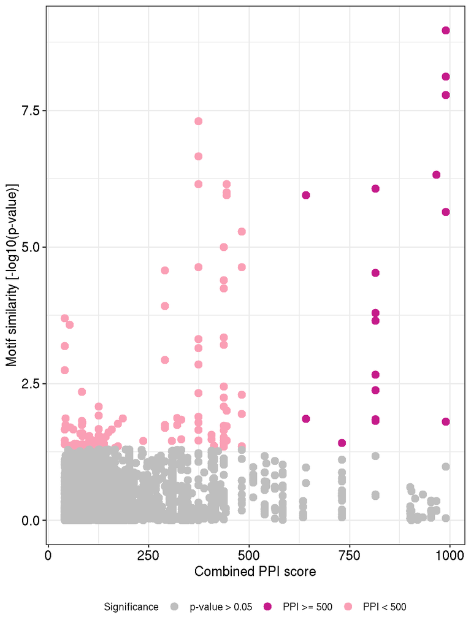

**Figure 5. PPI plot**. Without annotations, just colouring

```r
ppi_plot <- ggplot(
    ppi_table,
    aes(
        x     = combined_score,
        y     = log10_p_value,
        label = pair_label)) +
    geom_point(
        aes(
            color = dplyr::case_when(
                ppi_table$log10_p_value  < -log10(0.05) ~ "grey",
                ppi_table$combined_score >= 500 ~ "#c51b8a",
                ppi_table$combined_score < 500 ~ "#fa9fb5")),
            size        = 3,
            show.legend = TRUE) +
    scale_color_identity(
        name   = "Significance",
        breaks = c("grey", "#c51b8a", "#fa9fb5"),
        labels = c("p-value > 0.05", "PPI >= 500", "PPI < 500"),
        guide  = "legend") +
    xlab("Combined PPI score") +
    ylab("Motif similarity [-log10(p-value)]") +
    theme(legend.position = "bottom")

ppi_plot
```

### Selectively plotting point labels

We add annotations for the most interesting points in the plot - top most significant motif matches with highest and lowest PPI scores. For this we use `geom_text_repel`, so the labels do not overlap. We will do data filtering withing ggplot command.

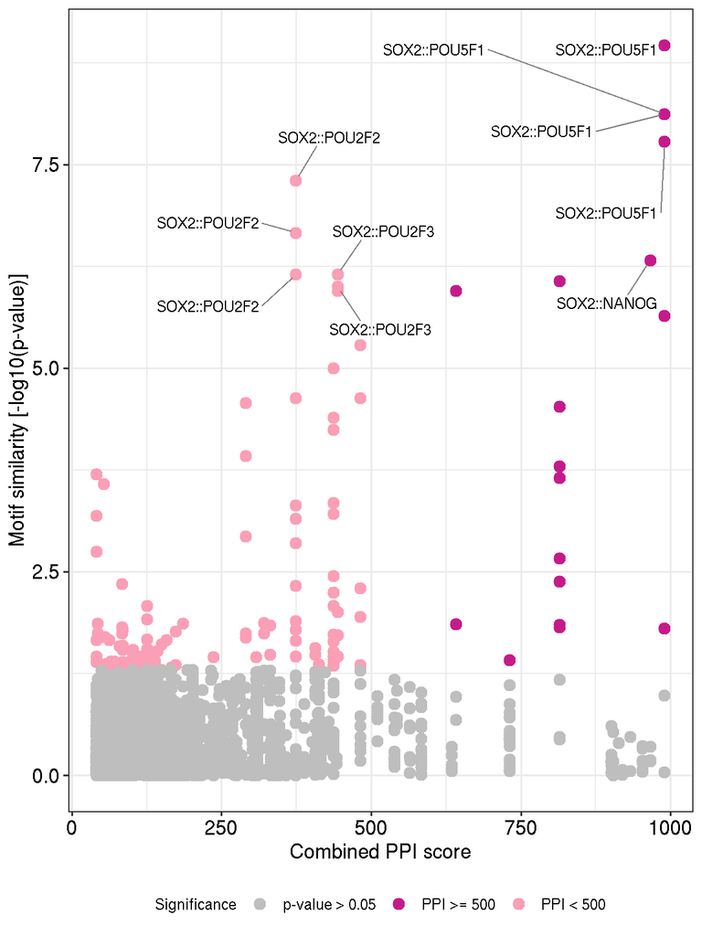

**Figure 5. PPI plot**. With top points annotations

```r
n_align <- 5 ## Number of matches to annotate

ppi_plot <- ppi_plot +
    geom_text_repel(
        data          = top_n(
            ppi_table[(ppi_table$log10_p_value  > -log10(0.05)) & (ppi_table$combined_score >= 500), ],
            as.numeric(n_align),
            log10_p_value),
        size          = 4,
        box.padding   = 1.5,
        point.padding = 0.3,
        segment.size  = 0.3,
        segment.color = "grey50") +
    geom_text_repel(
        data          = top_n(
            ppi_table[(ppi_table$log10_p_value > -log10(0.05)) & (ppi_table$combined_score < 500), ],
            as.numeric(n_align),
            log10_p_value),
        size          = 4,
        box.padding   = 1.5,
        point.padding = 0.3,
        segment.size  = 0.3,
        segment.color = "grey50")

ppi_plot
```

### Annotating plots with motif alignment images

To annotate the plot with logos we need to prepare some data for those logo images to be inserted into. For this we build a data frame with top logo information, we extract the path to the images and we define the order of their appearance in the plot.

```r
match_images          <- rbind(
    ppi_table[(ppi_table$log10_p_value > -log10(0.05)) & (ppi_table$combined_score >= 500), ][1:n_align, ],
    ppi_table[(ppi_table$log10_p_value) > -log10(0.05) & (ppi_table$combined_score < 500), ][1:n_align, ]
)
match_images          <- match_images[!is.na(match_images$alignment_png), ]
match_alignment_paths <- match_images
match_images          <- match_images %>%
                            dplyr::select(-alignment_png) %>%
                            unique()

match_images   <- match_images %>%
                mutate(freq  = 1) %>%
                mutate(label = paste0(
                    stringr::str_split_fixed(pair_label, "::", n = 2)[,2],
                    "\n(",
                    cobinder_motif_id,
                    ")\n\n",
                    gsub(cobinder_id, pattern = "cobinder_", replacement = "Co-binding "),
                    "\n")) %>%
                arrange(log10_p_value)
align_order    <- unique(as.vector(match_images$label))
```

| cobinder_id | cobinder_name | cobinder_motif_id | log10_p_value | log10_E_value | log10_q_value | tf_pair | pair_label | combined_score | TOMTOMbyPPI | freq | label |
| --- | --- | --- | --- | --- | --- | --- | --- | --- | --- | --- | --- |
| cobinder_0 | POU2F3 | MA0627.2 | 6.00421173260997 | 2.1840100667979 | 3.02895806511923 | SOX2::POU2F3 | SOX2::POU2F3 | 444 | 2.66587000927883 | 1 | POU2F3 (MA0627.2) Co-binding 0 |
| cobinder_0 | POU2F2 | M05446_2.00 | 6.15033924205649 | 2.33013850053365 | 3.02910804046927 | SOX2::POU2F2 | SOX2::POU2F2 | 374 | 2.30022687652913 | 1 | POU2F2 (M05446_2.00) Co-binding 0 |
| cobinder_0 | POU2F3 | M05468_2.00 | 6.15033924205649 | 2.33013850053365 | 3.02910804046927 | SOX2::POU2F3 | SOX2::POU2F3 | 444 | 2.73075062347308 | 1 | POU2F3 (M05468_2.00) Co-binding 0 |
| cobinder_0 | NANOG | M09139_2.00 | 6.32170018889701 | 2.50149784742358 | 3.10355866561505 | SOX2::NANOG | SOX2::NANOG | 966 | 6.10676238247451 | 1 | NANOG (M09139_2.00) Co-binding 0 |
| cobinder_0 | POU2F2 | M03298_2.00 | 6.66412305190505 | 2.84392052824579 | 3.38798902737079 | SOX2::POU2F2 | SOX2::POU2F2 | 374 | 2.49238202141249 | 1 | POU2F2 (M03298_2.00) Co-binding 0 |
| cobinder_0 | POU2F2 | M09218_2.00 | 7.30123676905334 | 3.48103620617949 | 3.95815746089915 | SOX2::POU2F2 | SOX2::POU2F2 | 374 | 2.73066255162595 | 1 | POU2F2 (M09218_2.00) Co-binding 0 |
| cobinder_0 | POU5F1 | M07976_2.00 | 7.78067224967528 | 3.96047087742204 | 4.35841187737259 | SOX2::POU5F1 | SOX2::POU5F1 | 990 | 7.70286552717853 | 1 | POU5F1 (M07976_2.00) Co-binding 0 |
| cobinder_0 | POU5F1 | M08141_2.00 | 8.12309545468518 | 4.30289450987158 | 4.47898489660213 | SOX2::POU5F1 | SOX2::POU5F1 | 990 | 8.04186450013833 | 1 | POU5F1 (M08141_2.00) Co-binding 0 |
| cobinder_0 | POU5F1 | MA1115.1 | 8.12309545468518 | 4.30289450987158 | 4.47898489660213 | SOX2::POU5F1 | SOX2::POU5F1 | 990 | 8.04186450013833 | 1 | POU5F1 (MA1115.1) Co-binding 0 |
| cobinder_0 | POU5F1 | M09222_2.00 | 8.96527932072869 | 5.14507666635339 | 4.84404788377538 | SOX2::POU5F1 | SOX2::POU5F1 | 990 | 8.8756265275214 | 1 | POU5F1 (M09222_2.00) Co-binding 0 |

**Table 4. Motif alignment information**. This table will be used to plot the images

To plot the images, we need to build an empty plot with the data that we can use as coordinates for logo insertion. We will plot this empty plot from the data frame we build in earlier step.

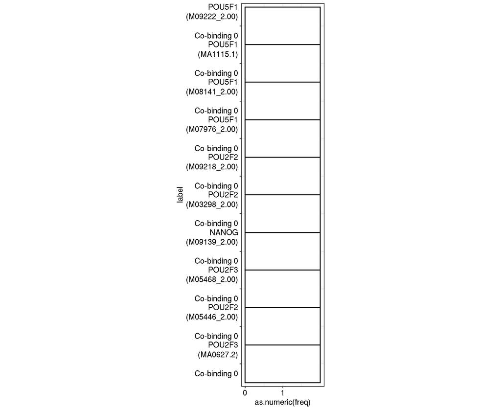

**Figure 6. Tile plot that will be used to insert logos**

```r
empty_tile_plot <- ggplot(
    data  = match_images,
    aes(
        x = as.numeric(freq),
        y = label,
        fill = "A")) +
    geom_tile(
        color = "black",
        fill = "white",
        size = 0.7,
        aes(width = 2, height = 1)) +
    coord_equal(clip = "off") +
    scale_y_discrete(limits = align_order) +
    scale_x_continuous(limits = c(0, 2), breaks = c(0, 1))

empty_tile_plot
```

Now we will insert logos one by one, based on the tile plot we built above. To insert `png` image we need to read it first, for which we use `png` R library. Then we use `annotation_raster` [function](https://ggplot2.tidyverse.org/reference/annotation_raster.html) from `ggplot2` to insert images one-by-one. Since all alignment logos are assumed to be of same dimensions, it is quite easy to determine their coordinates (we made these assumptions when building the dataframe).

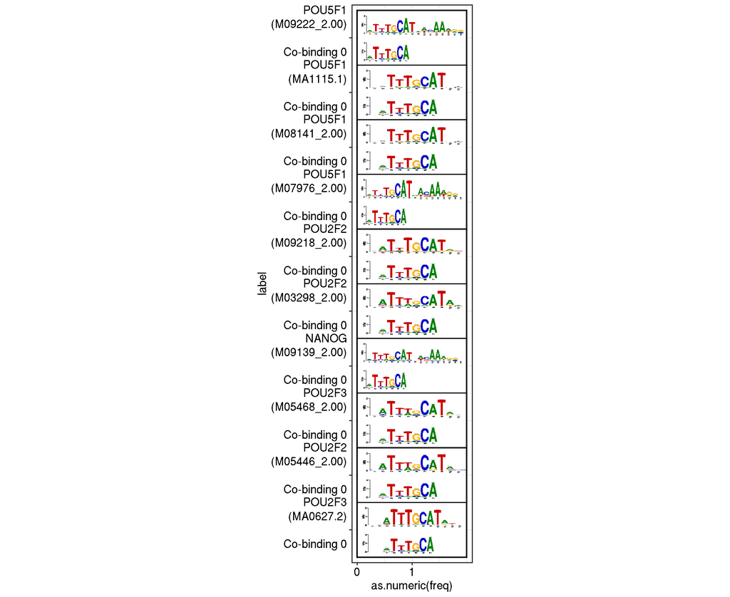

**Figure 7. Tile plot with inserted logos**

```r
## Selecting only necessary columns:
match_images <- match_images %>%
    dplyr::select(cobinder_motif_id,
                    label) %>%
    unique()

## Inerting logo one-by-one:
plotted_logos <- empty_tile_plot

for (k in 1:nrow(match_images)) {

    motif_info <- match_images[k, ]
    alignment  <- match_alignment_paths[grepl(
        pattern = motif_info$cobinder_motif_id,
        x       = match_alignment_paths$cobinder_motif_id), ]
    logo       <- alignment$alignment_png[1]
    logo.png   <- png::readPNG(logo)

    plotted_logos <- plotted_logos +
        ggplot2::annotation_raster(
            logo.png,
            xmin = 0.01, xmax = 1.99,
            ymin = k - 0.49, ymax = k + 0.49)
}

plotted_logos
```

We want to polish this tile plot with motifs a little bit, so we remove axis titles and choose an “empty” theme.

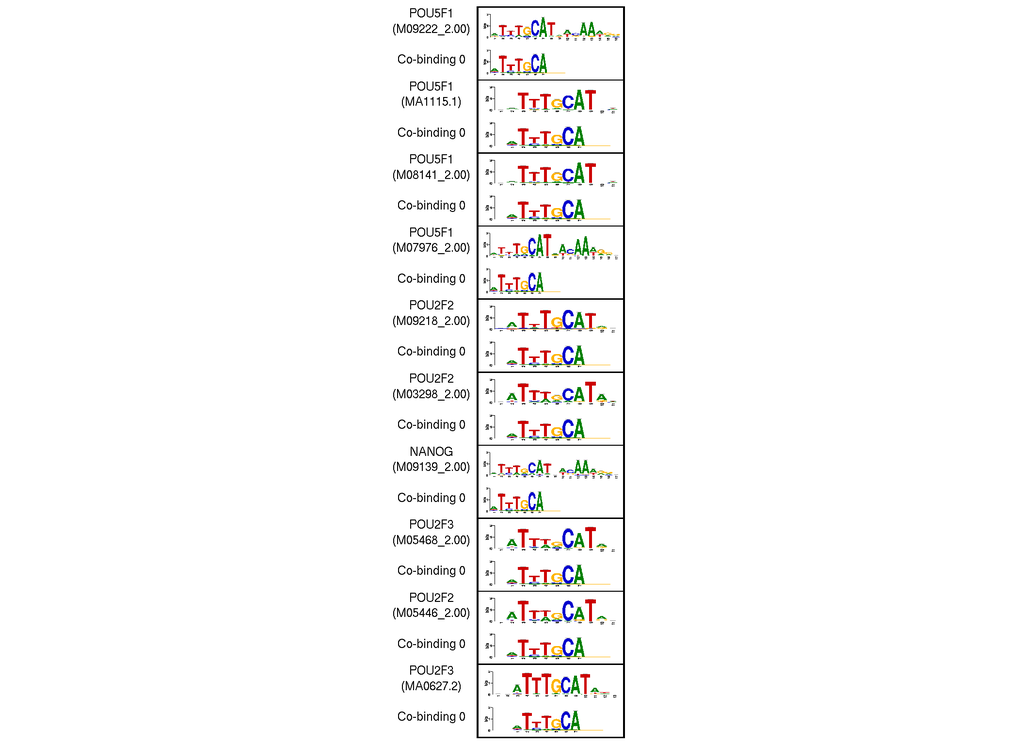

**Figure 8. Polished tile plot with inserted logos**

```r
plotted_logos <- plotted_logos +
    theme_void() +
    theme(
        axis.text.y = element_text(colour = "black"),
        axis.title.x = element_blank())

plotted_logos
```

Now we will combine the PPI plot with out plotted logos to generate final plot.

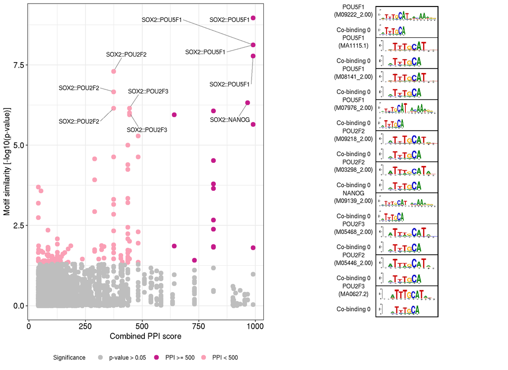

**Figure 9. Final PPI plot with logo annotations.**

```r
ppi_plot_with_logos <- plot_grid(
    ppi_plot, plotted_logos,
    ncol = 2,
    nrow = 1,
    rel_widths = c(1, 0.9),
    align = "h",
    axis = "tblr"
)

ppi_plot_with_logos
```

```r
## Expporting the plot:
ggsave(
    plot      = conservation_plot,
    filename  = file.path("ppi_plot_with_logo_annotations.pdf"),
    width     = 7,
    height    = 6,
    limitsize = FALSE)
```